# VLM Wrong Predictions: attr_bridge_type [both_right]

Actual: Beam

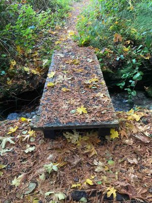

29219__AST_IM_20211021_143332.jpeg

Asset 92801 3 images

Predicted: VLM: Beam | DINOv3: Beam (conf: N/A)

Actual: Beam

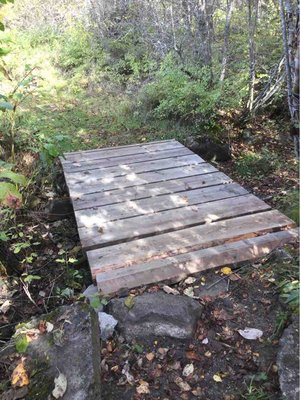

29224__AST_IM_20211012_113547.jpeg

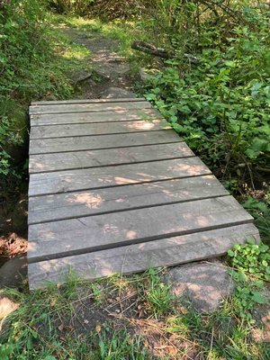

55915__AST_EX_20220726_094520.jpeg

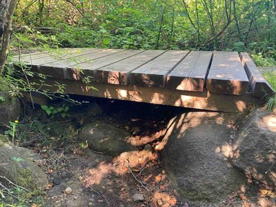

55918__AST_EX_20220726_094541.jpeg

Asset 92854 7 images

Predicted: VLM: Beam | DINOv3: Beam (conf: N/A)

Actual: Beam

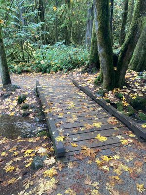

29466__AST_IM_20211026_111254.jpeg

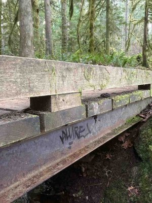

78656__AST_EX_20250123_152953.jpeg

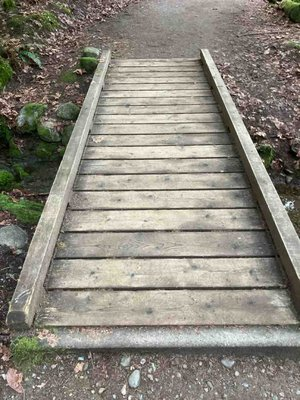

78659__AST_EX_20250123_153004.jpeg

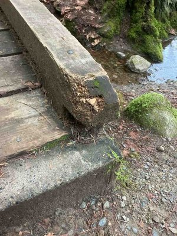

78660__AST_EX_20250123_153113.jpeg

[figure not shown]

78661__AST_EX_20250123_153104.jpeg

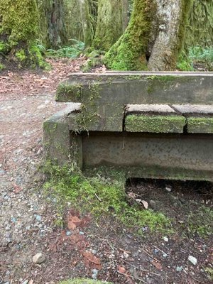

78662__AST_EX_20250123_152944.jpeg

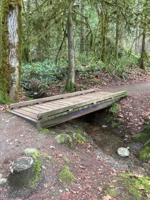

78664__AST_EX_20250123_152826.jpeg

Asset 92872 1 image

Predicted: VLM: Beam | DINOv3: Beam (conf: N/A)

Actual: Beam

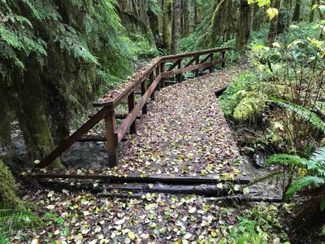

29477__AST_IM_20211022_120746.jpeg

Asset 93036 1 image

Predicted: VLM: Beam | DINOv3: Beam (conf: N/A)

Actual: Beam

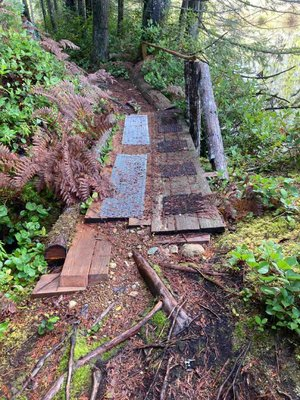

29706__AST_IM_20211029_125434.jpeg

Asset 93038 1 image

Predicted: VLM: Beam | DINOv3: Beam (conf: N/A)

Actual: Beam

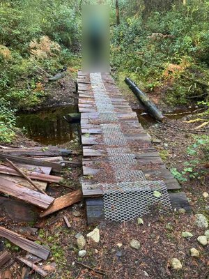

29700__AST_IM_20211029_141824.jpeg

Asset 93043 1 image

Predicted: VLM: Beam | DINOv3: Beam (conf: N/A)

Actual: Beam

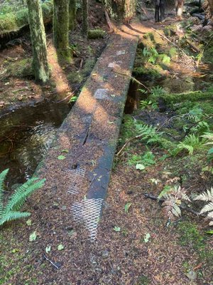

29697__AST_IM_20211029_132630.jpeg

Asset 96292 1 image

Predicted: VLM: Beam | DINOv3: Beam (conf: N/A)

Actual: Beam

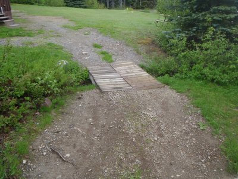

35807__P6110130.JPG

Asset 96854 2 images

Predicted: VLM: Beam | DINOv3: Beam (conf: N/A)

Actual: Beam

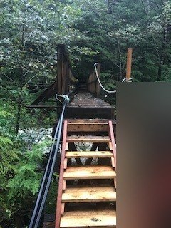

36702__emily_lake_2.jpg

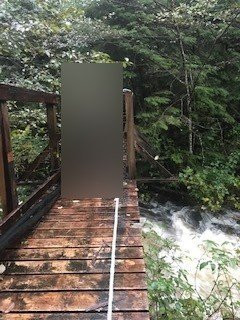

36703__emily_lake_3.jpg

Asset 98336 2 images

Predicted: VLM: Beam | DINOv3: Beam (conf: N/A)

Actual: Beam

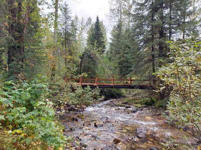

40065__Fang_Bridge.jpg

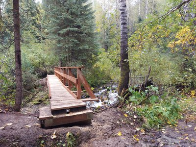

40066__Fang_Bridge_2.jpg

Asset 98498 1 image

Predicted: VLM: Beam | DINOv3: Beam (conf: N/A)

Actual: Beam

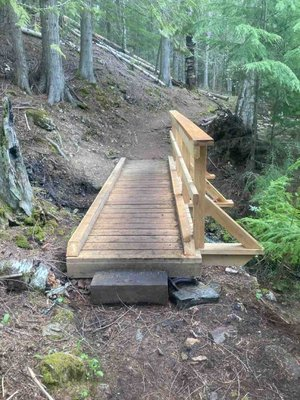

40292__AST_IM_20220504_112521.jpeg

Asset 100272 2 images

Predicted: VLM: Beam | DINOv3: Beam (conf: N/A)

Actual: Beam

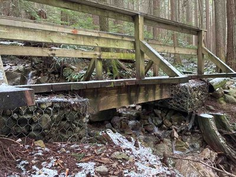

92644__AST_EX_20260218_140920.jpeg

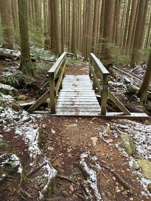

92645__AST_EX_20260218_140858.jpeg

Asset 100347 2 images

Predicted: VLM: Beam | DINOv3: Beam (conf: N/A)

Actual: Beam

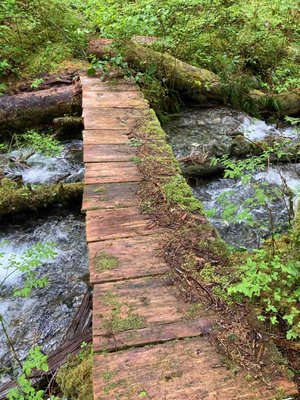

44047__AST_IM_20220601_123719.jpeg

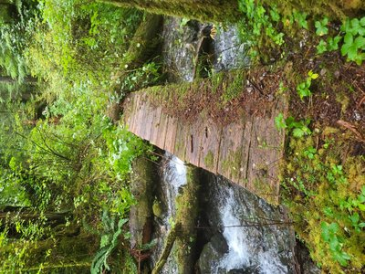

74872__bridge4.jpg

Asset 100446 2 images

Predicted: VLM: Beam | DINOv3: Beam (conf: N/A)

Actual: Beam

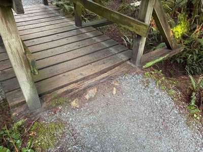

92627__AST_EX_20260217_152139.jpeg

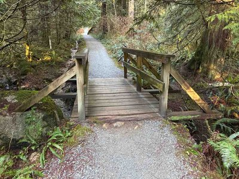

92628__AST_EX_20260217_152037.jpeg

Asset 100757 1 image

Predicted: VLM: Beam | DINOv3: Beam (conf: N/A)

Actual: Beam

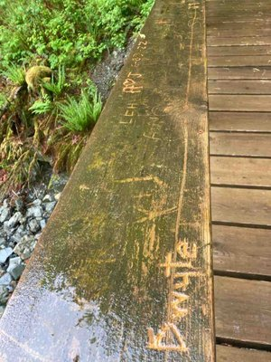

44511__AST_IM_20220603_122949.jpeg

Asset 100758 1 image

Predicted: VLM: Beam | DINOv3: Beam (conf: N/A)

Actual: Beam

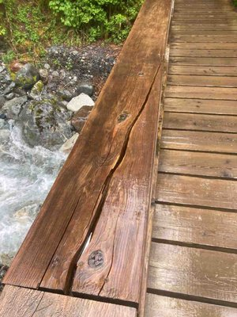

44512__AST_IM_20220603_124827.jpeg

Asset 101132 4 images

Predicted: VLM: Beam | DINOv3: Beam (conf: N/A)

Actual: Beam

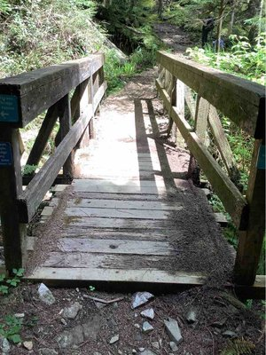

45173__AST_IM_20220607_124950.jpeg

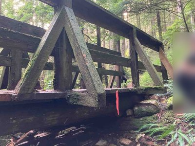

78080__AST_EX_20241211_132206.jpeg

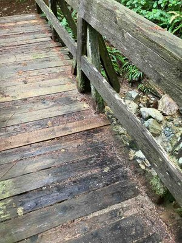

78085__AST_EX_20241211_132243.jpeg

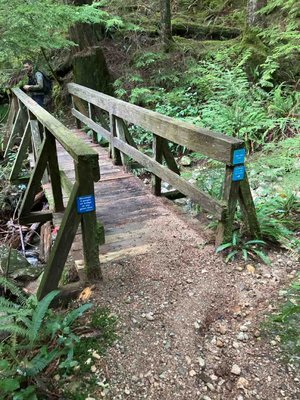

78086__AST_EX_20241211_131833.jpeg

Asset 101826 1 image

Predicted: VLM: Suspension | DINOv3: Suspension (conf: N/A)

Actual: Suspension

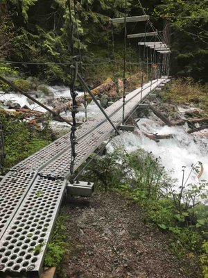

45984__AST_IM_20220612_131542.jpeg

Asset 101890 1 image

Predicted: VLM: Beam | DINOv3: Beam (conf: N/A)

Actual: Beam

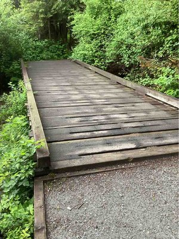

46058__AST_IM_20220613_105948.jpeg

Asset 101988 1 image

Predicted: VLM: Beam | DINOv3: Beam (conf: N/A)

Actual: Beam

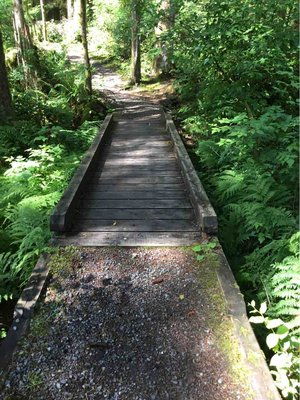

46170__AST_IM_20220614_104016.jpeg

Asset 102341 1 image

Predicted: VLM: Beam | DINOv3: Beam (conf: N/A)

Actual: Beam

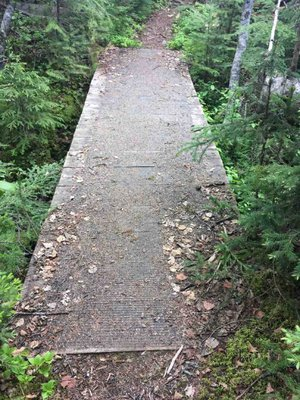

46520__AST_IM_20220615_103955.jpeg

Asset 102344 1 image

Predicted: VLM: Beam | DINOv3: Beam (conf: N/A)

Actual: Beam

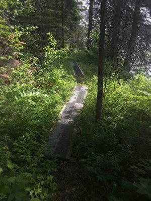

46488__AST_IM_20220615_115431.jpeg